# Titanic Wrangling

Author

Deepika Agarwal

Link to Github Repo : https://github.com/deepikaagarwal02/PracticeActivity2.1

In this practice activity you’ll continue to work with the titanic dataset in ways that flex what you’ve learned about both data wrangling and data visualization.

```python
# Import the titanic dataset here
import numpy as np
import pandas as pd

data_dir = "https://dlsun.github.io/pods/data/"
df_titanic = pd.read_csv(data_dir + "titanic.csv")

df_titanic.head()
```

|  | name | gender | age | class | embarked | country | ticketno | fare | survived |
| --- | --- | --- | --- | --- | --- | --- | --- | --- | --- |
| 0 | Abbing, Mr. Anthony | male | 42.0 | 3rd | S | United States | 5547.0 | 7.11 | 0 |
| 1 | Abbott, Mr. Eugene Joseph | male | 13.0 | 3rd | S | United States | 2673.0 | 20.05 | 0 |
| 2 | Abbott, Mr. Rossmore Edward | male | 16.0 | 3rd | S | United States | 2673.0 | 20.05 | 0 |
| 3 | Abbott, Mrs. Rhoda Mary 'Rosa' | female | 39.0 | 3rd | S | England | 2673.0 | 20.05 | 1 |
| 4 | Abelseth, Miss. Karen Marie | female | 16.0 | 3rd | S | Norway | 348125.0 | 7.13 | 1 |

```python
df_titanic["name"][(df_titanic["age"] < 20) & (df_titanic["survived"] == 1)]
```

|  | name |
| --- | --- |
| 4 | Abelseth, Miss. Karen Marie |
| 13 | Aks, Master. Frank Philip |
| 14 | Aks, Mrs. Leah |
| 22 | Allison, Master. Hudson Trevor |
| 28 | Andersen-Jensen, Miss. Carla Christine Nielsine |
| ... | ... |
| 1485 | Collins, Mr. John |
| 1520 | Daniels, Mr. Sidney Edward |
| 1708 | Hyland, Mr. James Leo |
| 1934 | Perry, Mr. Edgar Lionel |
| 2166 | Whiteley, Mr. Thomas Arthur |

123 rows × 1 columns

**dtype:** object

## 1. Filter the data to include passengers only. Calculate the joint distribution (cross-tab) between a passenger’s class and where they embarked.

```python
# Create filters for each passenger class
first_class = df_titanic['class'] == "1st"
second_class = df_titanic['class'] == "2nd"
third_class = df_titanic['class'] == "3rd"

# Apply above filters to extract passenger data
df_passengers = df_titanic[first_class | second_class | third_class]
df_passengers.head()
```

|  | name | gender | age | class | embarked | country | ticketno | fare | survived |
| --- | --- | --- | --- | --- | --- | --- | --- | --- | --- |
| 0 | Abbing, Mr. Anthony | male | 42.0 | 3rd | S | United States | 5547.0 | 7.11 | 0 |
| 1 | Abbott, Mr. Eugene Joseph | male | 13.0 | 3rd | S | United States | 2673.0 | 20.05 | 0 |
| 2 | Abbott, Mr. Rossmore Edward | male | 16.0 | 3rd | S | United States | 2673.0 | 20.05 | 0 |
| 3 | Abbott, Mrs. Rhoda Mary 'Rosa' | female | 39.0 | 3rd | S | England | 2673.0 | 20.05 | 1 |
| 4 | Abelseth, Miss. Karen Marie | female | 16.0 | 3rd | S | Norway | 348125.0 | 7.13 | 1 |

```python
# Create crosstsab between passenger class and where they embarked
df_joint = pd.crosstab(df_passengers["class"], df_passengers["embarked"], normalize = True)
df_joint
```

| embarked class | B | C | Q | S |
| --- | --- | --- | --- | --- |
| 1st | 0.002278 | 0.108580 | 0.002278 | 0.132878 |
| 2nd | 0.004556 | 0.019742 | 0.005315 | 0.186029 |
| 3rd | 0.000000 | 0.077449 | 0.085801 | 0.375095 |

## 2. Using the joint distribution that calculated above, calculate the following:

- the conditional distribution of their class given where they embarked
- the conditional distribution of where they embarked given their class

Use the conditional distributions that you calculate to answer the following quesitons:

- What proportion of 3rd class passengers embarked at Southampton?
- What proportion of Southampton passengers were in 3rd class?

```python
# Conditional distribution of passenger class given they embarked at "B"
df_embarked_B = df_joint["B"]/df_joint["B"].sum()
display(df_embarked_B)

# Conditional distribution of passenger class given they embarked at "C"
df_embarked_C = df_joint["C"]/df_joint["C"].sum()
display(df_embarked_C)

# Conditional distribution of passenger class given they embarked at "Q"
df_embarked_Q = df_joint["Q"]/df_joint["Q"].sum()
display(df_embarked_Q)

# Conditional distribution of passenger class given they embarked at "S"
df_embarked_S = df_joint["S"]/df_joint["S"].sum()
display(df_embarked_S)
```

| class | B |
| --- | --- |
| 1st | 0.333333 |
| 2nd | 0.666667 |
| 3rd | 0.000000 |

**dtype:** float64

| class | C |
| --- | --- |
| 1st | 0.527675 |
| 2nd | 0.095941 |
| 3rd | 0.376384 |

**dtype:** float64

| class | Q |
| --- | --- |
| 1st | 0.024390 |
| 2nd | 0.056911 |
| 3rd | 0.918699 |

**dtype:** float64

| class | S |
| --- | --- |
| 1st | 0.191466 |
| 2nd | 0.268053 |
| 3rd | 0.540481 |

**dtype:** float64

```python
# Conditional distribution of where they embarked given 1st class
df_class_1 = df_joint.loc["1st"]/df_joint.loc["1st"].sum()
display(df_class_1)

# Conditional distribution of where they embarked given 2nd class
df_class_2 = df_joint.loc["2nd"]/df_joint.loc["2nd"].sum()
display(df_class_2)

# Conditional distribution of where they embarked given 3rd class
df_class_3 = df_joint.loc["3rd"]/df_joint.loc["3rd"].sum()
display(df_class_3)
```

| embarked | 1st |
| --- | --- |
| B | 0.009259 |
| C | 0.441358 |
| Q | 0.009259 |
| S | 0.540123 |

**dtype:** float64

| embarked | 2nd |
| --- | --- |
| B | 0.021127 |
| C | 0.091549 |
| Q | 0.024648 |
| S | 0.862676 |

**dtype:** float64

| embarked | 3rd |
| --- | --- |
| B | 0.000000 |
| C | 0.143865 |
| Q | 0.159379 |
| S | 0.696756 |

**dtype:** float64

What proportion of 3rd class passengers embarked at Southampton? 69.67%

## 3. Make a visualization showing the distribution of a passenger’s class, given where they embarked.

Discuss the pros and cons of using this visualization versus the distributions you calculated before, to answer the previous questions.

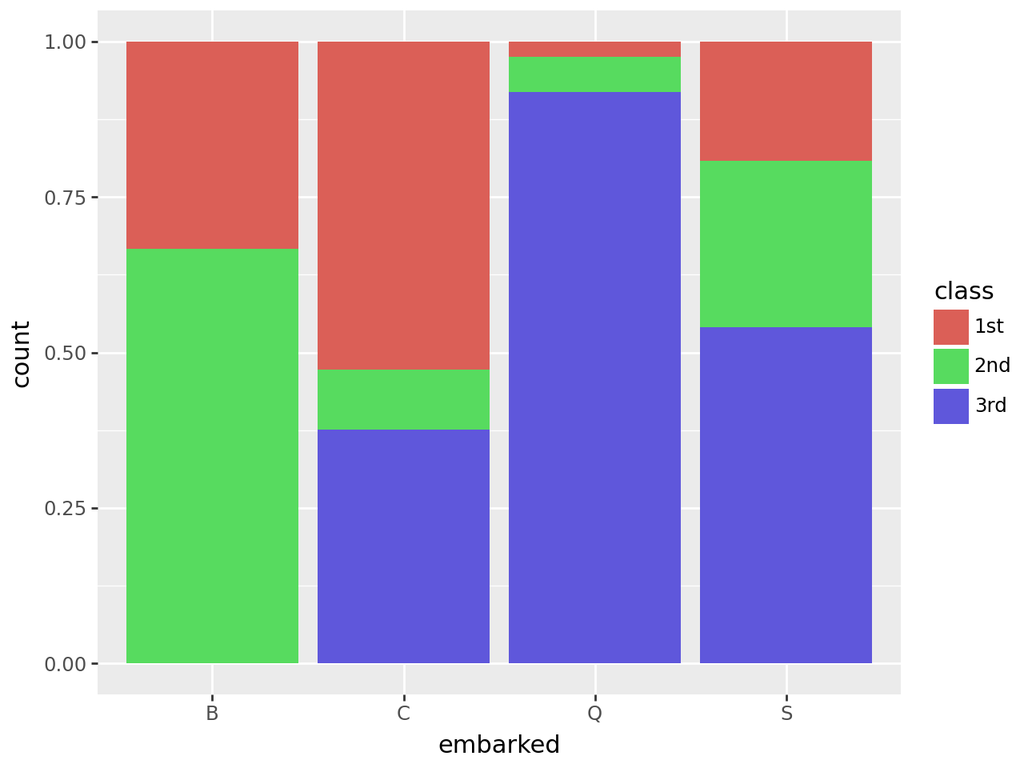

```python
from plotnine import ggplot, geom_bar, aes
(ggplot(df_passengers,
aes(
  x = "embarked",
  fill = "class"
))
+ geom_bar(position = "fill")
)
```